# Tutorial - R

Blakemore Lab - Emily Towner

January 29, 2021

# Install and load the necessary packages

This will vary based on the tasks you will do in R for this script

```r
# This installs them (only need to do this once)
# install.packages('tidyverse')
# install.packages('afex')
# install.packages('emmeans')
# install.packages('meta')

# This loads the package (need to do this every time you restart R)
library(tidyverse)
library(psych)
library(afex)
library(emmeans)
library(meta)
library(lm.beta)
```

# Read in the data

Data should usually be in .csv format

```r
# This reads in from your working directory - if using R-Markdown will be the root folder
data <- read.csv("data.csv")
data_meta <- read.csv("data_meta.csv")
```

# Summarize numeric data

```r
# The 'psych' package has a nice function 'describe'
describe(data)
```

```
##                   vars   n  mean    sd median trimmed   mad   min    max  range
## participant          1 150 75.50 43.45  75.50   75.50 55.60  1.00 150.00 149.00
## group*               2 150  2.00  0.82   2.00    2.00  1.48  1.00   3.00   2.00
## sex*                 3 150  1.47  0.50   1.00    1.47  0.00  1.00   2.00   1.00
## age                  4 150 16.04  4.13  16.00   15.87  4.45 10.00  24.00  14.00
## anxiety              5 150 75.88 15.21  76.28   76.15 15.24 41.24 111.48  70.23
## depression           6 150 54.32 15.52  54.09   54.08 14.60 15.08 107.93  92.85
## early_life_stress    7 150 49.61 13.38  48.94   49.35 12.33 18.57  88.58  70.01
## test_score           8 150 79.21 11.22  79.00   79.51 13.34 51.00  99.00  48.00
##                    skew kurtosis   se
## participant        0.00    -1.22 3.55
## group*             0.00    -1.52 0.07
## sex*               0.11    -2.00 0.04
## age                0.28    -0.94 0.34
## anxiety           -0.09    -0.39 1.24
## depression         0.23     0.58 1.27
## early_life_stress  0.17     0.07 1.09
## test_score        -0.22    -0.77 0.92
```

```r
# We have two 'factor' variables - group and sex, but wait, participant should also be treated as a factor, what is it now?

class(data$participant)
```

```
## [1] "integer"
```

```r
# R is treating it as an integer, so we will want to fix that

data$participant <- as.factor(data$participant)

# Check if it worked

class(data$participant)
```

```
## [1] "factor"
```

```r
# What are the levels of our 'factor' variables - group and sex

levels(data$sex)
```

```
## [1] "Female" "Male"
```

```r
levels(data$group)
```

```
## [1] "Early-Adolescence" "Late-Adolescence"  "Mid-Adolescence"
```

```r
# Cool, we have groups by stage of adolescence, what are the age ranges for those groups?

range(data$age[data$group == "Early-Adolescence"])
```

```
## [1] 10 13
```

```r
range(data$age[data$group == "Mid-Adolescence"])
```

```
## [1] 14 17
```

```r
range(data$age[data$group == "Late-Adolescence"])
```

```
## [1] 18 24
```

```r
# How many are in each group?

count(data[data$group == "Early-Adolescence",])
```

```
##    n
## 1 50
```

```r
count(data[data$group == "Mid-Adolescence",])
```

```
##    n
## 1 50
```

```r
count(data[data$group == "Late-Adolescence",])
```

```
##    n
## 1 50
```

# Look at data distributions

A good first step before analysis.

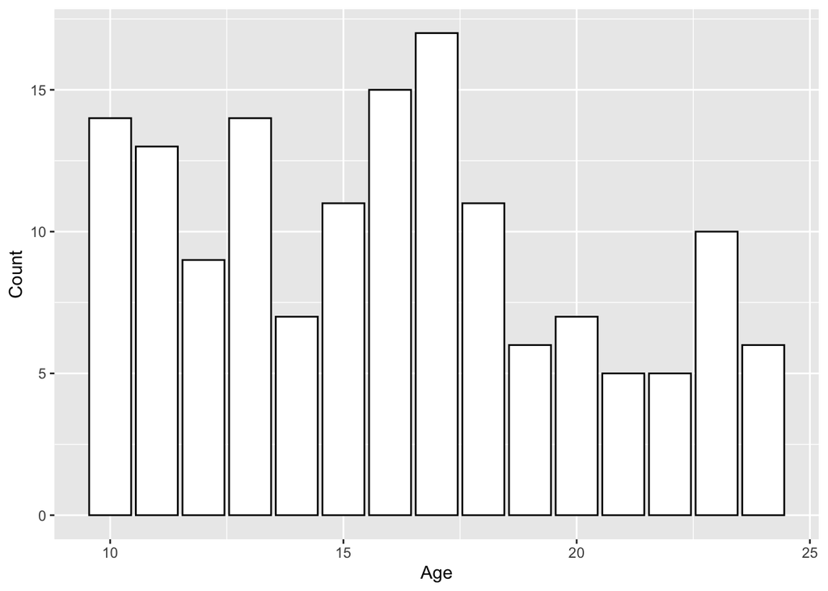

```r
ggplot(data, aes(x=age)) +
  geom_histogram(color = "black", fill = "white", stat = "count") +
  labs(x = "Age", y = "Count")
```

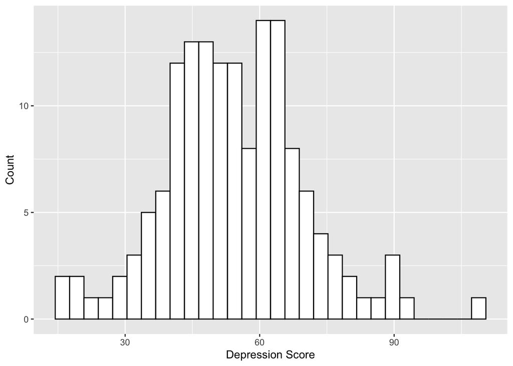

```r
ggplot(data, aes(x=depression)) +
  geom_histogram(color = "black", fill = "white") +
  labs(x = "Depression Score", y = "Count")
```

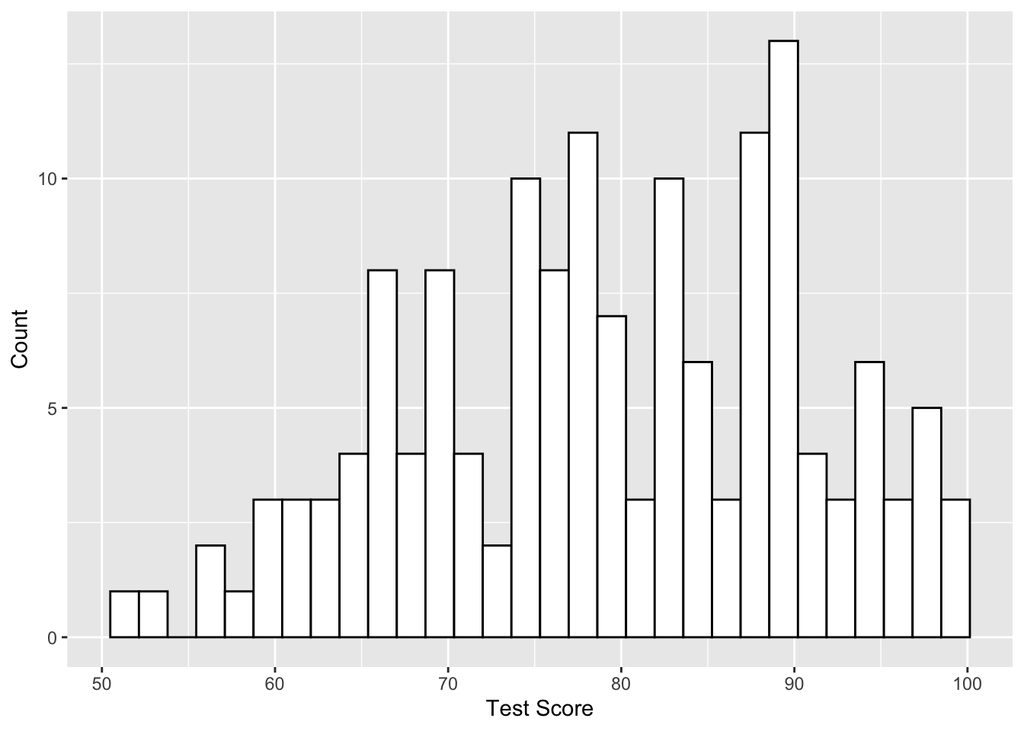

```r
ggplot(data, aes(x=test_score)) +
  geom_histogram(color = "black", fill = "white") +
  labs(x = "Test Score", y = "Count")
```

# Inferential statistics

Perhaps we want to know whether the level of reported anxiety is different between early adolescents, mid adolescents, and late adolescents. Since we have more than 2 groups, we need to do an anova instead of a t-test.

```r
my_anova <- aov_ez(data = data, dv = "anxiety", id = "participant", between = "group")
my_anova
```

```
## Anova Table (Type 3 tests)
##
## Response: anxiety
##   Effect     df    MSE         F  ges p.value
## 1  group 2, 147 189.20 17.58 *** .193   <.001
## ---
## Signif. codes:  0 '***' 0.001 '**' 0.01 '*' 0.05 '+' 0.1 ' ' 1
```

We can see that we have a statistically significant difference between our groups, let’s see what the means of each group are.

```r
means_table <- emmeans(my_anova, ~ group)
means_table
```

```
##  group             emmean   SE  df lower.CL upper.CL
##  Early-Adolescence   75.3 1.95 147     71.4     79.1
##  Late-Adolescence    68.0 1.95 147     64.2     71.9
##  Mid-Adolescence     84.3 1.95 147     80.5     88.2
##
## Confidence level used: 0.95
```

Now let’s do post-hoc comparisons using Tukey’s test.

```r
TukeyHSD(my_anova$aov)
```

```
##   Tukey multiple comparisons of means
##     95% family-wise confidence level
##
## Fit: aov(formula = tmp_formula, data = dat.ret, contrasts = contrasts)
##
## $group
##                                         diff        lwr        upr     p adj
## Late-Adolescence-Early-Adolescence -7.230484 -13.744062 -0.7169061 0.0255642
## Mid-Adolescence-Early-Adolescence   9.047981   2.534403 15.5615596 0.0035834
## Mid-Adolescence-Late-Adolescence   16.278466   9.764888 22.7920439 0.0000001
```

We can see that all the groups are statistically significantly different from each other.

# Visualizing the data

## Plotting means

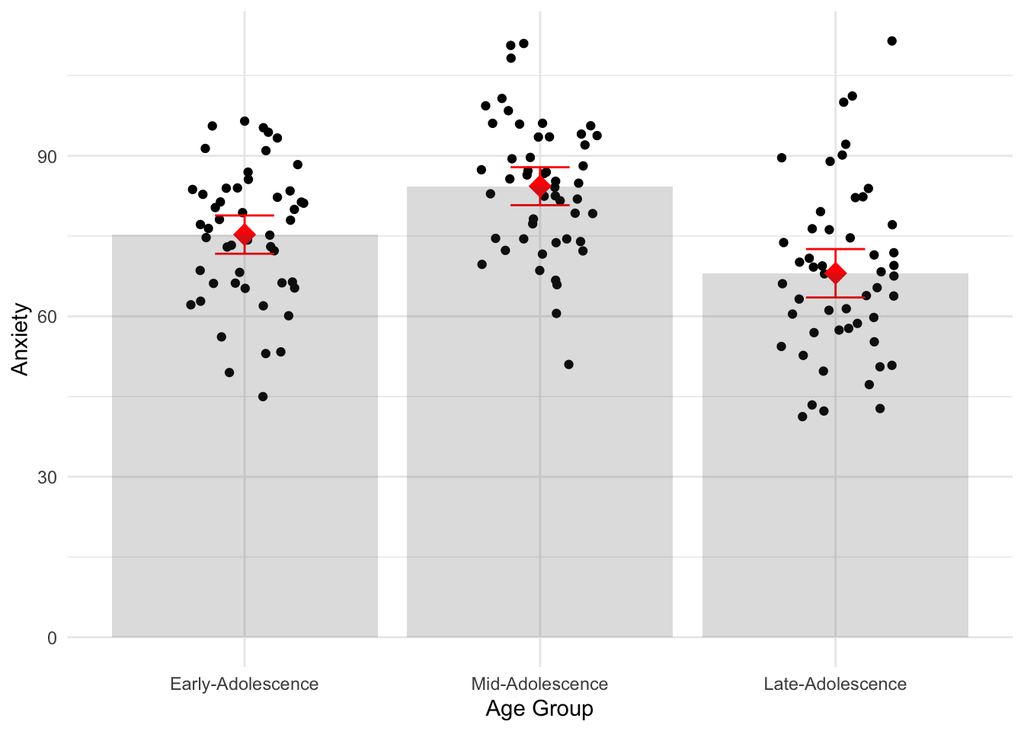

```r
data$group <- factor(data$group, levels = c("Early-Adolescence", "Mid-Adolescence", "Late-Adolescence"))
ggplot(data, aes(x=group, y=anxiety)) +
  geom_point(position = position_jitter(width = .2)) +
  stat_summary(fun.y = mean, geom = "point", shape = "diamond", size = 5, color = "red") +
  stat_summary(fun.data = mean_cl_normal, geom = "errorbar", width = .2, color = "red") +
  stat_summary(fun.y = mean, geom = "bar", alpha = 0.2) +
  labs(x = "Age Group", y = "Anxiety") +
  theme_minimal()
```

Say we want to split by sex, and look at the data this way.

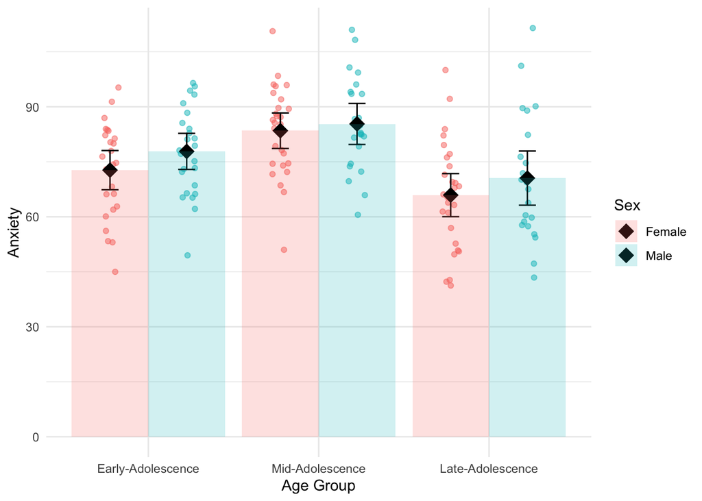

```r
ggplot(data, aes(x=group, y=anxiety, fill = sex, color = sex)) +
  geom_point(position = position_jitterdodge(dodge.width = .9, jitter.width = .2), alpha = 0.5) +
  stat_summary(fun.y = mean, geom = "point", shape = "diamond", size = 5, position = position_dodge(width = .9), color = "black") +
  stat_summary(fun.data = mean_cl_normal, geom = "errorbar", width = .2, position = position_dodge(width = .9), color = "black") +
  stat_summary(fun.y = mean, geom = "bar", alpha = 0.2, position = position_dodge(width = .9), color = NA) +
  labs(x = "Age Group", y = "Anxiety", fill = "Sex", color = "Sex") +
  theme_minimal()
```

## Plotting associations

Let’s look at the association between anxiety and depression in this sample.

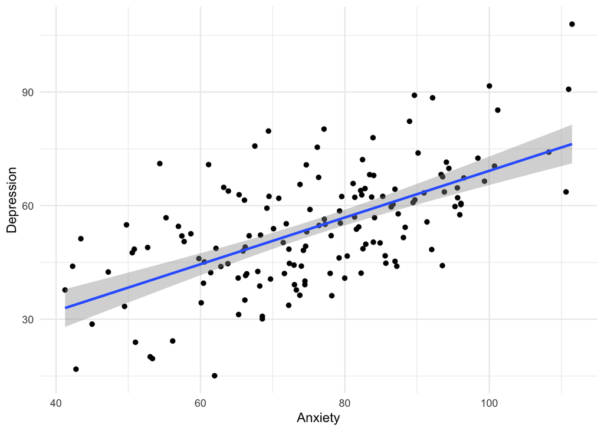

```r
ggplot(data, aes(x=anxiety, y=depression)) +
  geom_point() +
  geom_smooth(method = "lm") +
  labs(x = "Anxiety", y = "Depression") +
  theme_minimal()
```

That looks like a pretty strong correlation - let’s test it statistically.

```r
cor.test(data$anxiety, data$depression)
```

```
##
##  Pearson's product-moment correlation
##
## data:  data$anxiety and data$depression
## t = 9.2269, df = 148, p-value = 2.668e-16
## alternative hypothesis: true correlation is not equal to 0
## 95 percent confidence interval:
##  0.4916533 0.6970546
## sample estimates:
##       cor
## 0.6043001
```

We can also split these correlation plots in many of the same ways.

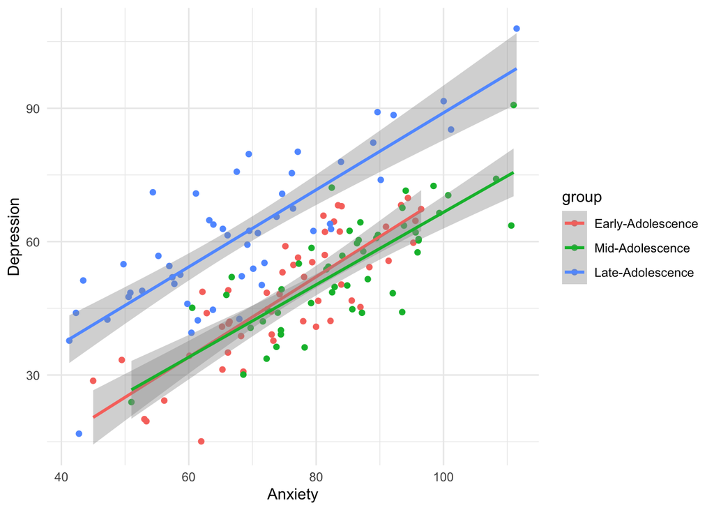

```r
ggplot(data, aes(x=anxiety, y=depression, color = group)) +
  geom_point() +
  geom_smooth(method = "lm") +
  labs(x = "Anxiety", y = "Depression") +
  theme_minimal()
```

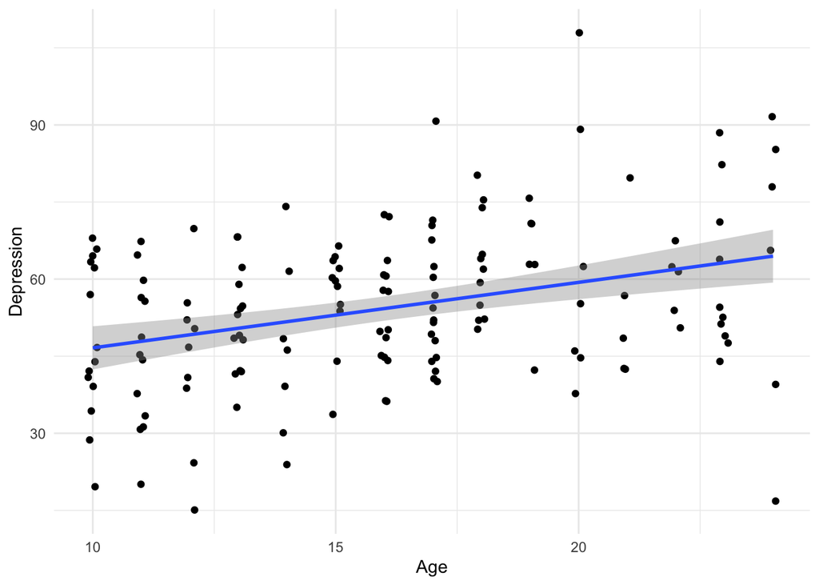

```r
ggplot(data, aes(x=age, y=depression)) +
  geom_point(position = position_jitter(width = .1)) +
  geom_smooth(method = "lm") +
  labs(x = "Age", y = "Depression") +
  theme_minimal()
```

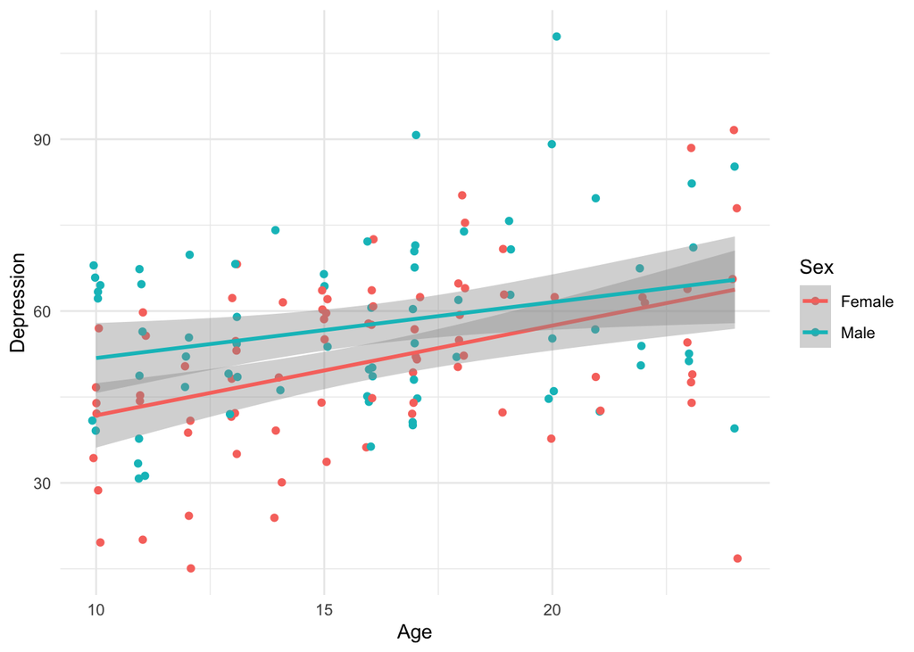

```r
ggplot(data, aes(x=age, y=depression, color = sex)) +
  geom_point(position = position_jitter(width = .1)) +
  geom_smooth(method = "lm") +
  labs(x = "Age", y = "Depression", color = "Sex") +
  theme_minimal()
```